# TWS workshop: Coding Session 2

Avgar, Fieberg & Signer

September 2019

Get started and load libraries

```r
knitr::opts_chunk$set(fig.width=12,fig.height=4.5, cache = TRUE)

library(raster)
library(tidyverse)
library(lubridate)
library(amt)
library(glmmTMB)
library(tictoc)
```

# Dealing with multiple animals

```r
env <- read_rds(here::here("data/env_covar.rds"))
trk <- read_rds(here::here("data/trk.rds"))

summarize_sampling_rate_many(trk, "id")
```

```
## # A tibble: 8 x 10
##   id    min       q1      median  mean    q3      max        sd     n unit
##   <fct> <table>   <table> <table> <table> <table> <table> <dbl> <int> <chr>
## 1 M1    13.26666… 14.733… 15.033… 32.745… 15.450…  976.7… 104.    918 min
## 2 M4     0.09996…  1.933…  2.033…  8.041…  2.566… 1208.5…  44.0  8957 min
## 3 F2     0.40000…  1.966…  2.033…  8.930…  3.983… 1079.9…  48.1  3003 min
## 4 M3     0.41666…  1.966…  2.166… 13.252…  5.416… 2888.6…  90.2  2435 min
## 5 F3     0.41661…  1.966…  2.066… 15.678…  4.083… 2167.4… 104.   1500 min
## 6 M2     1.34998…  9.783… 10.016… 21.729… 10.333… 2110.8…  87.2  1637 min
## 7 F1     3.91666…  9.799… 10.016… 20.693… 10.299… 1650.3…  95.2  1348 min
## 8 M5     0.24995…  1.933…  2.016…  7.408…  2.366…  976.3…  25.0 13098 min
```

```r
dat1 <- trk %>% nest(data = -id)
# This is a temporary fix
class(dat1) <- c("tbl_df", "tbl", "data.frame")
dat1
```

```
## # A tibble: 8 x 2
##   id              data
##   <fct> <list<df[,4]>>
## 1 M1         [919 × 4]
## 2 M4       [8,958 × 4]
## 3 F2       [3,004 × 4]
## 4 M3       [2,436 × 4]
## 5 F3       [1,501 × 4]
## 6 M2       [1,638 × 4]
## 7 F1       [1,349 × 4]
## 8 M5      [13,099 × 4]
```

Add a column with the animal’s sex

```r
dat1 <- dat1 %>% mutate(sex = str_sub(id, 1, 1))
dat1
```

```
## # A tibble: 8 x 3
##   id              data sex
##   <fct> <list<df[,4]>> <chr>
## 1 M1         [919 × 4] M
## 2 M4       [8,958 × 4] M
## 3 F2       [3,004 × 4] F
## 4 M3       [2,436 × 4] M
## 5 F3       [1,501 × 4] F
## 6 M2       [1,638 × 4] M
## 7 F1       [1,349 × 4] F
## 8 M5      [13,099 × 4] M
```

## RSF

We now repeat the same steps as before. Just that this time we have to loop over each animal. There are several ways how to achieve this. We use the `map` funciton (which is equivalent to the `lappaly` function).

```r
dat2 <- dat1 %>%
  mutate(dat_resample = map(data, ~ track_resample(., rate = minutes(30), tolerance = minutes(2))))
dat2
```

```
## # A tibble: 8 x 4
##   id              data sex   dat_resample
##   <fct> <list<df[,4]>> <chr> <list>
## 1 M1         [919 × 4] M     <tibble [484 × 5]>
## 2 M4       [8,958 × 4] M     <tibble [1,240 × 5]>
## 3 F2       [3,004 × 4] F     <tibble [424 × 5]>
## 4 M3       [2,436 × 4] M     <tibble [357 × 5]>
## 5 F3       [1,501 × 4] F     <tibble [197 × 5]>
## 6 M2       [1,638 × 4] M     <tibble [601 × 5]>
## 7 F1       [1,349 × 4] F     <tibble [473 × 5]>
## 8 M5      [13,099 × 4] M     <tibble [1,984 × 5]>
```

Now fit for each animal a RSF

```r
dat2 <- dat2 %>%
  mutate(rsf = map(dat_resample, function(x) x %>% random_points %>% extract_covariates(env) %>%
                     fit_rsf(case_ ~ elevation + pop_den + forest)))
dat2 <- dat2 %>% mutate(rsf = map(rsf, ~ broom::tidy(.$model))) %>%
  unnest(cols = rsf) %>%
  filter(term != "(Intercept)") # remove estimate for the intercept
dat2
```

```
## # A tibble: 24 x 9
##    id           data sex   dat_resample term  estimate std.error statistic
##    <fct> <list<df[,> <chr> <list>       <chr>    <dbl>     <dbl>     <dbl>
##  1 M1      [919 × 4] M     <tibble [48… elev…  6.75e-2  0.00888      7.60
##  2 M1      [919 × 4] M     <tibble [48… pop_…  1.67e-3  0.000228     7.34
##  3 M1      [919 × 4] M     <tibble [48… fore…  3.68e-2  0.107        0.345
##  4 M4    [8,958 × 4] M     <tibble [1,… elev…  5.76e-3  0.00173      3.33
##  5 M4    [8,958 × 4] M     <tibble [1,… pop_… -1.05e-3  0.000138    -7.63
##  6 M4    [8,958 × 4] M     <tibble [1,… fore…  1.14e+0  0.0631      18.2
##  7 F2    [3,004 × 4] F     <tibble [42… elev…  7.28e-2  0.00941      7.74
##  8 F2    [3,004 × 4] F     <tibble [42… pop_… -2.94e-4  0.000289    -1.02
##  9 F2    [3,004 × 4] F     <tibble [42… fore…  3.04e-2  0.113        0.269
## 10 M3    [2,436 × 4] M     <tibble [35… elev… -1.70e-2  0.00793     -2.14
## # … with 14 more rows, and 1 more variable: p.value <dbl>
```

Plotting results

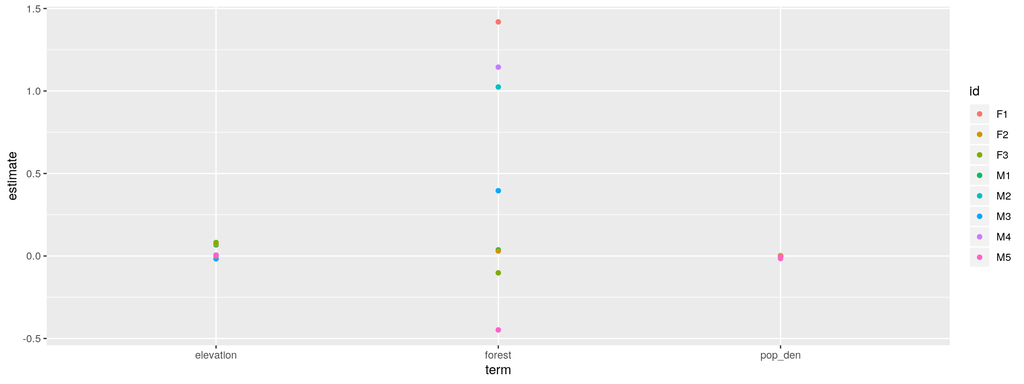

```r
ggplot(dat2, aes(term, estimate, col = id)) + geom_point()
```

better color by sex

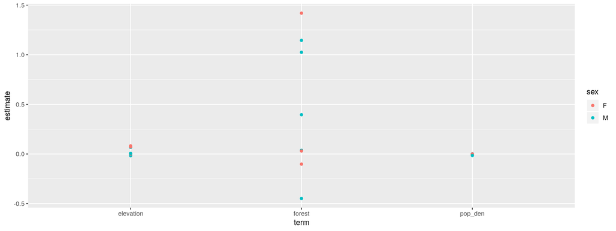

```r
ggplot(dat2, aes(term, estimate, col = sex)) + geom_point()
```

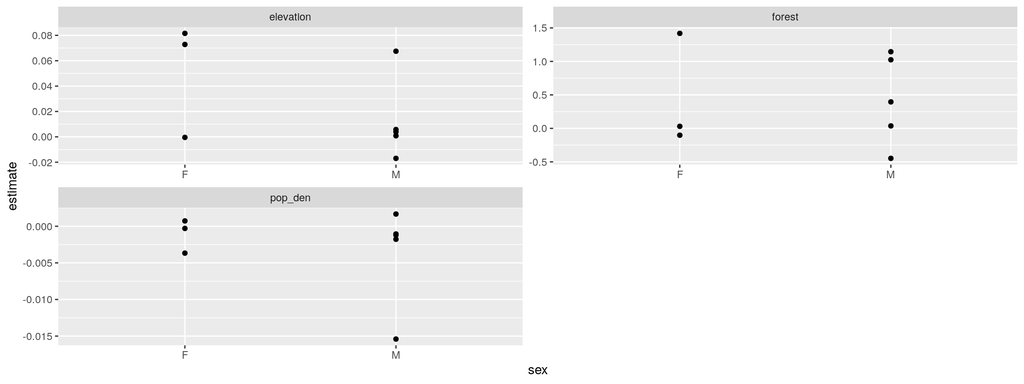

```r
ggplot(dat2, aes(sex, estimate)) + geom_point() +
  facet_wrap(~ term, scale = "free", ncol = 2)
```

Do statistics with coeffficients Bootstrap point and uncertainty estimate Lets do one coefficient: elevation

```r
dat2 %>% filter(term == "elevation") %>% pull(estimate)
```

```
## [1]  0.0674905255  0.0057646781  0.0728297852 -0.0169594852  0.0815747123
## [6]  0.0008539594 -0.0004338035  0.0039854565
```

```r
pop_ele <- dat2 %>% filter(term == "elevation") %>% pull(estimate)

sample(pop_ele, 8, TRUE)
```

```
## [1]  0.0008539594 -0.0169594852  0.0008539594 -0.0169594852  0.0728297852
## [6]  0.0057646781  0.0039854565  0.0815747123
```

```r
mean(sample(pop_ele, 8, TRUE))
```

```
## [1] 0.0274942
```

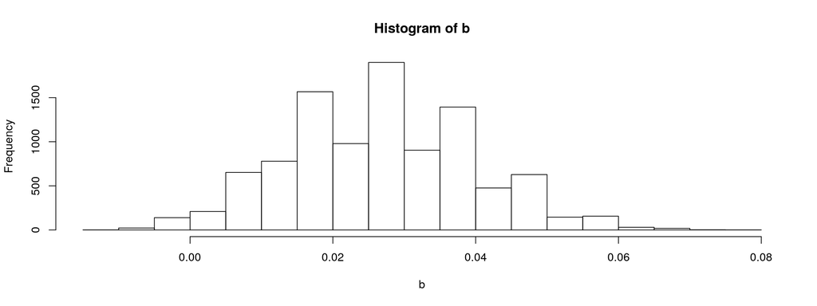

```r
b <- replicate(1e4, mean(sample(pop_ele, 8, TRUE)))
hist(b)
```

Now we can calcualte statistics from the bootstrap sample

```r
mean(b)
```

```
## [1] 0.02678005
```

```r
sd(b) # that is the SE
```

```
## [1] 0.01305039
```

```r
quantile(b, prob = c(0.025, 0.975))
```

```
##        2.5%       97.5%
## 0.002633657 0.054074405
```

```r
# Now for all three terms

res0 <- dat2 %>% select(id, term, estimate) %>%
  nest(data = c(id, estimate)) %>%
  mutate(boot = map(data, ~ replicate(1e4, mean(sample(.$estimate, 8, replace = TRUE)))),
         mean = map_dbl(boot, mean),
         se = map_dbl(boot, sd) )
res0
```

```
## # A tibble: 3 x 5
##   term                data boot               mean      se
##   <chr>     <list<df[,2]>> <list>            <dbl>   <dbl>
## 1 elevation        [8 × 2] <dbl [10,000]>  0.0268  0.0131
## 2 pop_den          [8 × 2] <dbl [10,000]> -0.00262 0.00179
## 3 forest           [8 × 2] <dbl [10,000]>  0.436   0.221
```

The same as above, but not breaking correlation between individuals

```r
est <- dat2 %>% select(id, term, estimate) %>% pivot_wider(names_from = term, values_from = estimate) %>%
  select(-id)
est1 <- replicate(1e4, colMeans(sample_n(est, nrow(est), TRUE)))
est1[1:3, 1:10]
```

```
##                   [,1]         [,2]         [,3]         [,4]
## elevation  0.028359663  0.038813566 6.027131e-02  0.039684279
## pop_den   -0.003642345 -0.001229487 8.397943e-05 -0.003445324
## forest     0.364534664  0.559429660 7.765043e-02  0.343791003
##                    [,5]         [,6]         [,7]         [,8]
## elevation  0.0220434303  0.038503324  0.004069237  0.034603959
## pop_den   -0.0007761184 -0.004214941 -0.007942735 -0.002283783
## forest     0.4644465702  0.207879556 -0.070994324  0.299128063
##                    [,9]        [,10]
## elevation  0.0409828200  0.026186550
## pop_den   -0.0003227516 -0.003906002
## forest     0.2803117431  0.270110046
```

```r
res0 <- tibble(
  term = rownames(est1),
  mean = apply(est1, 1, mean),
  se = apply(est1, 1, sd))


# Using this approach, we can easily add a second grouping variable (e.g., sex)
res1 <- dat2 %>% select(sex, term, estimate) %>%
  nest(data = estimate) %>%
  mutate(boot = map(data, ~ replicate(1e3, mean(sample(.$estimate, 8, replace = TRUE)))),
         mean = map_dbl(boot, mean),
         lci = map_dbl(boot, quantile, prob = 0.025),
         uci = map_dbl(boot, quantile, prob = 0.975))
res1
```

```
## # A tibble: 6 x 7
##   sex   term                data boot              mean      lci        uci
##   <chr> <chr>     <list<df[,1]>> <list>           <dbl>    <dbl>      <dbl>
## 1 M     elevation        [5 × 1] <dbl [1,000]>  0.0125  -0.00443  0.0332
## 2 M     pop_den          [5 × 1] <dbl [1,000]> -0.00349 -0.00827 -0.000121
## 3 M     forest           [5 × 1] <dbl [1,000]>  0.432    0.0234   0.823
## 4 F     elevation        [3 × 1] <dbl [1,000]>  0.0509   0.0281   0.0761
## 5 F     pop_den          [3 × 1] <dbl [1,000]> -0.00107 -0.00228  0.0000900
## 6 F     forest           [3 × 1] <dbl [1,000]>  0.440   -0.0193   0.882
```

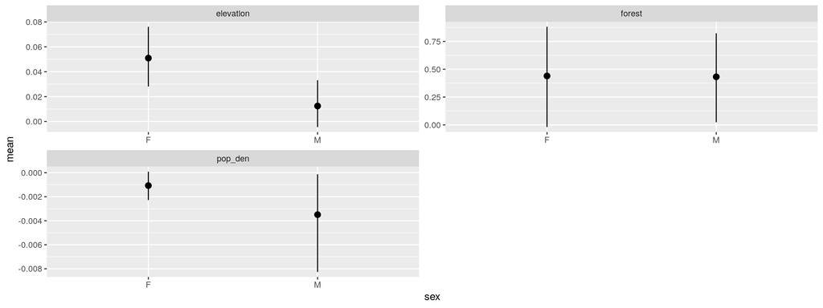

```r
ggplot(res1, aes(sex, mean, ymin = lci, ymax = uci)) + geom_pointrange() +
  facet_wrap(~ term, scale = "free", ncol = 2)
```

## Mixed effects model

```r
library(glmmTMB)
dat2 %>% mutate(dat_resample = map(data, ~ track_resample(., rate = minutes(30), tolerance = minutes(2))))
```

```
## # A tibble: 24 x 9
##    id           data sex   dat_resample term  estimate std.error statistic
##    <fct> <list<df[,> <chr> <list>       <chr>    <dbl>     <dbl>     <dbl>
##  1 M1      [919 × 4] M     <tibble [48… elev…  6.75e-2  0.00888      7.60
##  2 M1      [919 × 4] M     <tibble [48… pop_…  1.67e-3  0.000228     7.34
##  3 M1      [919 × 4] M     <tibble [48… fore…  3.68e-2  0.107        0.345
##  4 M4    [8,958 × 4] M     <tibble [1,… elev…  5.76e-3  0.00173      3.33
##  5 M4    [8,958 × 4] M     <tibble [1,… pop_… -1.05e-3  0.000138    -7.63
##  6 M4    [8,958 × 4] M     <tibble [1,… fore…  1.14e+0  0.0631      18.2
##  7 F2    [3,004 × 4] F     <tibble [42… elev…  7.28e-2  0.00941      7.74
##  8 F2    [3,004 × 4] F     <tibble [42… pop_… -2.94e-4  0.000289    -1.02
##  9 F2    [3,004 × 4] F     <tibble [42… fore…  3.04e-2  0.113        0.269
## 10 M3    [2,436 × 4] M     <tibble [35… elev… -1.70e-2  0.00793     -2.14
## # … with 14 more rows, and 1 more variable: p.value <dbl>
```

```r
dat3 <- dat2 %>%
  mutate(rsf = map(dat_resample, ~ .x %>% random_points %>% extract_covariates(env))) %>%
  select(id, rsf) %>% unnest(cols = rsf)
dat3
```

```
## # A tibble: 190,080 x 8
##    id    case_       x_       y_ elevation landuse pop_den forest
##    <fct> <lgl>    <dbl>    <dbl>     <dbl>   <dbl>   <dbl>  <dbl>
##  1 M1    TRUE  1782673. 2402297.     -176.      41    90.5      1
##  2 M1    TRUE  1782683. 2402292.     -176.      41    89.0      1
##  3 M1    TRUE  1782681. 2402297.     -176.      41    89.0      1
##  4 M1    TRUE  1782683. 2402298.     -176.      41    89.0      1
##  5 M1    TRUE  1782682. 2402290.     -176.      41    89.0      1
##  6 M1    TRUE  1782684. 2402298.     -176.      41    89.0      1
##  7 M1    TRUE  1782685. 2402274.     -177.      41    91.4      1
##  8 M1    TRUE  1782669. 2402309.     -176.      41    90.5      1
##  9 M1    TRUE  1782679. 2402299.     -176.      41    89.0      1
## 10 M1    TRUE  1782679. 2402304.     -176.      41    89.0      1
## # … with 190,070 more rows
```

```r
# This will take a few minutes again
```

```r
res1_rsf <- glmmTMB(case_ ~ elevation + forest + pop_den + (1|id)+ (0+elevation+forest  | id),
                    data = dat3, family = binomial(), doFit=FALSE)
```

Set variance of random intercept to 10^6

```r
res1_rsf$parameters$theta[1] <- log(1e3)
nvar_parm <- length(res1_rsf$parameters$theta)
res1_rsf$mapArg <- list(theta = factor(c(NA, 1:(nvar_parm - 1))))

tictoc::tic()
res1_rsf <- glmmTMB:::fitTMB(res1_rsf)
tictoc::toc()
```

```
## 235.959 sec elapsed
```

```r
summary(res1_rsf)
```

```
##  Family: binomial  ( logit )
## Formula:
## case_ ~ elevation + forest + pop_den + (1 | id) + (0 + elevation +
##     forest | id)
## Data: dat3
##
##      AIC      BIC   logLik deviance df.resid
## 112731.6 112802.7 -56358.8 112717.6   190073
##
## Random effects:
##
## Conditional model:
##  Groups Name        Variance  Std.Dev.  Corr
##  id     (Intercept) 1.000e+06 1.000e+03
##  id.1   elevation   1.435e-03 3.788e-02
##         forest      4.095e-01 6.399e-01 -0.55
## Number of obs: 190080, groups:  id, 8
##
## Conditional model:
##               Estimate Std. Error z value Pr(>|z|)
## (Intercept)  2.189e-04  3.536e+02   0.000   1.0000
## elevation    2.593e-02  1.357e-02   1.911   0.0560 .
## forest       4.334e-01  2.276e-01   1.905   0.0568 .
## pop_den     -7.392e-04  4.949e-05 -14.937   <2e-16 ***
## ---
## Signif. codes:  0 '***' 0.001 '**' 0.01 '*' 0.05 '.' 0.1 ' ' 1
```

Interaction with sex

```r
dat3<-dat3 %>% mutate(male=substr(id,1,1)=="M")
res1_rsf <- glmmTMB(case_ ~ elevation:male + forest + pop_den + (1|id)+ (0+forest  | id),
                    data = dat3, family = binomial(), doFit=FALSE)
```

Set variance of random intercept to 10^6

```r
res1_rsf$parameters$theta[1] <- log(1e3)
nvar_parm <- length(res1_rsf$parameters$theta)
res1_rsf$mapArg <- list(theta = factor(c(NA, 1:(nvar_parm - 1))))

tictoc::tic()
res1_rsf <- glmmTMB:::fitTMB(res1_rsf)
tictoc::toc()
```

```
## 223.235 sec elapsed
```

```r
summary(res1_rsf)
```

```
##  Family: binomial  ( logit )
## Formula:
## case_ ~ elevation:male + forest + pop_den + (1 | id) + (0 + forest |
##     id)
## Data: dat3
##
##      AIC      BIC   logLik deviance df.resid
## 113011.9 113072.9 -56500.0 112999.9   190074
##
## Random effects:
##
## Conditional model:
##  Groups Name        Variance  Std.Dev.
##  id     (Intercept) 1.000e+06 1000.0000
##  id.1   forest      3.437e-01    0.5863
## Number of obs: 190080, groups:  id, 8
##
## Conditional model:
##                       Estimate Std. Error z value Pr(>|z|)
## (Intercept)         -1.912e-05  3.536e+02   0.000   1.0000
## forest               4.641e-01  2.086e-01   2.224   0.0261 *
## pop_den             -8.126e-04  4.792e-05 -16.957   <2e-16 ***
## elevation:maleFALSE  2.251e-02  2.215e-03  10.167   <2e-16 ***
## elevation:maleTRUE   3.577e-03  2.230e-04  16.043   <2e-16 ***
## ---
## Signif. codes:  0 '***' 0.001 '**' 0.01 '*' 0.05 '.' 0.1 ' ' 1
```

# Step-Selection Functions

```r
env <- read_rds(here::here("data/env_covar.rds"))
trk <- read_rds(here::here("data/trk.rds"))

summarize_sampling_rate_many(trk, "id")
```

```
## # A tibble: 8 x 10
##   id    min       q1      median  mean    q3      max        sd     n unit
##   <fct> <table>   <table> <table> <table> <table> <table> <dbl> <int> <chr>
## 1 M1    13.26666… 14.733… 15.033… 32.745… 15.450…  976.7… 104.    918 min
## 2 M4     0.09996…  1.933…  2.033…  8.041…  2.566… 1208.5…  44.0  8957 min
## 3 F2     0.40000…  1.966…  2.033…  8.930…  3.983… 1079.9…  48.1  3003 min
## 4 M3     0.41666…  1.966…  2.166… 13.252…  5.416… 2888.6…  90.2  2435 min
## 5 F3     0.41661…  1.966…  2.066… 15.678…  4.083… 2167.4… 104.   1500 min
## 6 M2     1.34998…  9.783… 10.016… 21.729… 10.333… 2110.8…  87.2  1637 min
## 7 F1     3.91666…  9.799… 10.016… 20.693… 10.299… 1650.3…  95.2  1348 min
## 8 M5     0.24995…  1.933…  2.016…  7.408…  2.366…  976.3…  25.0 13098 min
```

```r
dat1 <- trk %>% nest(data = -id)
# This is a temporary fix
class(dat1) <- c("tbl_df", "tbl", "data.frame")
dat1
```

```
## # A tibble: 8 x 2
##   id              data
##   <fct> <list<df[,4]>>
## 1 M1         [919 × 4]
## 2 M4       [8,958 × 4]
## 3 F2       [3,004 × 4]
## 4 M3       [2,436 × 4]
## 5 F3       [1,501 × 4]
## 6 M2       [1,638 × 4]
## 7 F1       [1,349 × 4]
## 8 M5      [13,099 × 4]
```

Add a column with the animal’s sex

```r
dat1 <- dat1 %>% mutate(sex = str_sub(id, 1, 1))

dat2 <- dat1 %>%
  mutate(dat_resample = map(data, ~ track_resample(., rate = minutes(30), tolerance = minutes(2))))
dat2
```

```
## # A tibble: 8 x 4
##   id              data sex   dat_resample
##   <fct> <list<df[,4]>> <chr> <list>
## 1 M1         [919 × 4] M     <tibble [484 × 5]>
## 2 M4       [8,958 × 4] M     <tibble [1,240 × 5]>
## 3 F2       [3,004 × 4] F     <tibble [424 × 5]>
## 4 M3       [2,436 × 4] M     <tibble [357 × 5]>
## 5 F3       [1,501 × 4] F     <tibble [197 × 5]>
## 6 M2       [1,638 × 4] M     <tibble [601 × 5]>
## 7 F1       [1,349 × 4] F     <tibble [473 × 5]>
## 8 M5      [13,099 × 4] M     <tibble [1,984 × 5]>
```

Now fit for each animal a SSF

```r
names(env)
```

```
## [1] "elevation" "landuse"   "pop_den"   "forest"
```

```r
dat2 <- dat2 %>%
  mutate(ssf = map(dat_resample, ~ .x %>% steps_by_burst %>%
                     random_steps %>% extract_covariates(env) %>%
                     fit_ssf(case_ ~ elevation + pop_den + forest + strata(step_id_))))
res_ind <- dat2 %>% mutate(ssf = map(ssf, ~ broom::tidy(.$model))) %>%
  unnest(cols = ssf)

# Bootstrap coefficients
res1 <- res_ind %>% select(term, estimate) %>%
  nest(data = estimate) %>%
  mutate(boot = map(data, ~ replicate(1e3, mean(sample(.$estimate, 8, replace = TRUE)))),
         mean = map_dbl(boot, mean),
         lci = map_dbl(boot, quantile, prob = 0.025),
         uci = map_dbl(boot, quantile, prob = 0.975))
res1
```

```
## # A tibble: 3 x 6
##   term                data boot              mean      lci       uci
##   <chr>     <list<df[,1]>> <list>           <dbl>    <dbl>     <dbl>
## 1 elevation        [8 × 1] <dbl [1,000]>  0.0361   0.0148   0.0656
## 2 pop_den          [8 × 1] <dbl [1,000]> -0.00307 -0.00652 -0.000682
## 3 forest           [8 × 1] <dbl [1,000]>  0.483    0.220    0.733
```

### Poisosn trick

Next, we will use the Poisson trick and fit a poisson regression

```r
dat1
```

```
## # A tibble: 8 x 3
##   id              data sex
##   <fct> <list<df[,4]>> <chr>
## 1 M1         [919 × 4] M
## 2 M4       [8,958 × 4] M
## 3 F2       [3,004 × 4] F
## 4 M3       [2,436 × 4] M
## 5 F3       [1,501 × 4] F
## 6 M2       [1,638 × 4] M
## 7 F1       [1,349 × 4] F
## 8 M5      [13,099 × 4] M
```

```r
dat2 <- dat1 %>%
  mutate(dat_resample = map(data, ~ track_resample(., rate = minutes(30), tolerance = minutes(2))))
dat2
```

```
## # A tibble: 8 x 4
##   id              data sex   dat_resample
##   <fct> <list<df[,4]>> <chr> <list>
## 1 M1         [919 × 4] M     <tibble [484 × 5]>
## 2 M4       [8,958 × 4] M     <tibble [1,240 × 5]>
## 3 F2       [3,004 × 4] F     <tibble [424 × 5]>
## 4 M3       [2,436 × 4] M     <tibble [357 × 5]>
## 5 F3       [1,501 × 4] F     <tibble [197 × 5]>
## 6 M2       [1,638 × 4] M     <tibble [601 × 5]>
## 7 F1       [1,349 × 4] F     <tibble [473 × 5]>
## 8 M5      [13,099 × 4] M     <tibble [1,984 × 5]>
```

Now we extract the covariates

```r
dat2 <- dat2 %>%
  mutate(ssf = map(dat_resample, ~ .x %>% steps_by_burst %>%
                     random_steps %>% extract_covariates(env)))
```

Next, unnest the data, and add for each step a unique id

```r
dat3 <- dat2 %>% select(ssf, id) %>% unnest(cols = ssf) %>%
  mutate(step_id = paste0(id, "-", step_id_))
```

The process is the same as for the mixed RSF:

```r
tic()
res1_ssf <- glmmTMB(case_ ~ elevation + pop_den + forest + (1|step_id) + (0 + elevation|id) +
                      (0 + pop_den | id) + ( 0 + forest  | id), family=poisson(),
                    data = dat3, doFit=FALSE)
```

Set variance of random intercept to 10^6

```r
res1_ssf$parameters$theta[1] <- log(1e3)
nvar_parm <- length(res1_ssf$parameters$theta)
res1_ssf$mapArg <- list(theta = factor(c(NA, 1:(nvar_parm - 1))))
res1_ssf <- glmmTMB:::fitTMB(res1_ssf)
summary(res1_ssf)
```

```
##  Family: poisson  ( log )
## Formula:
## case_ ~ elevation + pop_den + forest + (1 | step_id) + (0 + elevation |
##     id) + (0 + pop_den | id) + (0 + forest | id)
## Data: dat3
##
##      AIC      BIC   logLik deviance df.resid
##  54669.9  54727.9 -27328.0  54655.9    29253
##
## Random effects:
##
## Conditional model:
##  Groups  Name        Variance  Std.Dev.
##  step_id (Intercept) 1.000e+06 1.000e+03
##  id      elevation   1.771e-04 1.331e-02
##  id.1    pop_den     6.085e-08 2.467e-04
##  id.2    forest      1.124e-01 3.353e-01
## Number of obs: 29260, groups:  step_id, 2660; id, 8
##
## Conditional model:
##               Estimate Std. Error z value Pr(>|z|)
## (Intercept) -0.0079977 19.4009670   0.000 0.999671
## elevation    0.0189393  0.0071191   2.660 0.007806 **
## pop_den     -0.0011562  0.0003433  -3.368 0.000757 ***
## forest       0.4893300  0.1357324   3.605 0.000312 ***
## ---
## Signif. codes:  0 '***' 0.001 '**' 0.01 '*' 0.05 '.' 0.1 ' ' 1
```

```r
toc()
```

```
## 32.724 sec elapsed
```

### Comparisons

```r
# Mean coefficient from individual fits
ssf_coefs <- res_ind %>% select(id, term, estimate) %>%
  group_by(term) %>% summarise(
  mean = mean(estimate),
  se = sd(estimate) / sqrt(n()))

res_ind
```

```
## # A tibble: 24 x 11
##    id           data sex   dat_resample term  estimate std.error statistic
##    <fct> <list<df[,> <chr> <list>       <chr>    <dbl>     <dbl>     <dbl>
##  1 M1      [919 × 4] M     <tibble [48… elev…  4.77e-2  0.0148       3.24
##  2 M1      [919 × 4] M     <tibble [48… pop_… -4.26e-4  0.000506    -0.842
##  3 M1      [919 × 4] M     <tibble [48… fore…  1.09e-1  0.147        0.742
##  4 M4    [8,958 × 4] M     <tibble [1,… elev…  2.19e-3  0.00538      0.407
##  5 M4    [8,958 × 4] M     <tibble [1,… pop_… -1.02e-3  0.000446    -2.29
##  6 M4    [8,958 × 4] M     <tibble [1,… fore…  7.85e-1  0.114        6.86
##  7 F2    [3,004 × 4] F     <tibble [42… elev…  4.53e-2  0.0171       2.65
##  8 F2    [3,004 × 4] F     <tibble [42… pop_… -1.30e-3  0.000881    -1.48
##  9 F2    [3,004 × 4] F     <tibble [42… fore…  5.00e-1  0.192        2.60
## 10 M3    [2,436 × 4] M     <tibble [35… elev…  3.23e-2  0.0213       1.51
## # … with 14 more rows, and 3 more variables: p.value <dbl>,
## #   conf.low <dbl>, conf.high <dbl>
```

```r
# Population mean coefficient from mixed modeL
summary(res1_ssf)$coef$cond[-1, "Estimate"]
```

```
##    elevation      pop_den       forest
##  0.018939258 -0.001156182  0.489329993
```

```r
# Variance of coefficientS from mixed model
summary(res1_ssf)$varcor #var
```

```
##
## Conditional model:
##  Groups  Name        Std.Dev.
##  step_id (Intercept) 1.0000e+03
##  id      elevation   1.3309e-02
##  id.1    pop_den     2.4667e-04
##  id.2    forest      3.3528e-01
```

Look at individual coefficients

```r
comp <- bind_rows(
  tibble(
    id = res_ind$id,
    term = res_ind$term,
    estimate = res_ind$estimate,
    method = rep("ind", nrow(res_ind))
  ),
  coef(res1_ssf)$cond$id[ , -1] %>% rownames_to_column("id") %>%
    pivot_longer(-id, names_to = "term", values_to = "estimate") %>%
    mutate(method = "ME")
)
```

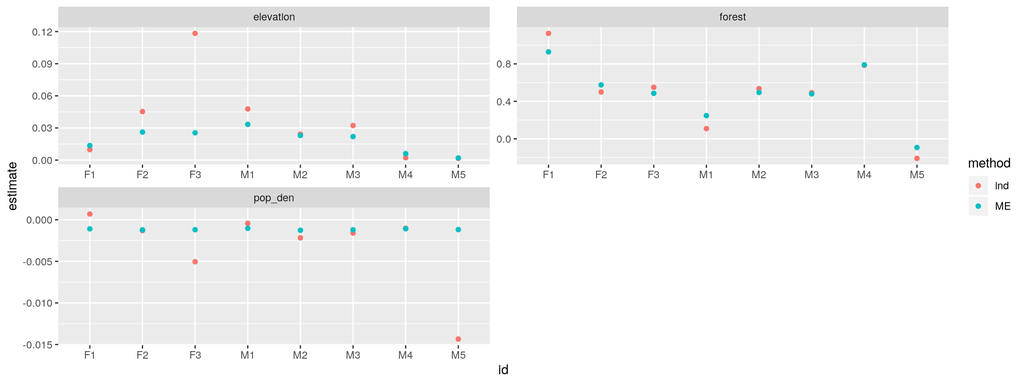

```r
comp %>% ggplot(aes(id, estimate, col = method)) + geom_point() +
  facet_wrap(~ term, scale = "free", ncol = 2)
```